# Final Report

Justin Ford

2026-01-02

This is the final report for my final project in Data Science 1 Spring 2024. I chose to use multiple NBA datasets from Kaggle.com to observe statistics from the previous two seasons (2021-2022 & 2022-2023). The following is what I found after researching and cleaning:

This study & dataset explores the different relationships between significant statistics in the National Basketball Association. Things such as 3 Point Percentage (3PT%), Free Throw Percentage (FT%), Points Per Game (PPG), along with many others. The objective of my research is to investigate the links between different variables, predict values for performance indeicators, and apply an advanced prediction method to gain insight into a player or another similar stat.

We begin with an observation on 3PT% and Position on the court. This will look at how each position is a factor for what your 3PT% will be:

```r
pos_vs_3pt <- data_2022_2023_NBA_Player_Stats_Regular %>% select(Pos, `3P%`) %>%
  mutate(`3P%` = case_when(`3P%`<0.25 ~ "0% to 25%  ",
                           `3P%`<0.5 ~ "25% to 50%  ",
                           `3P%`<0.75 ~ "50% to 75%  ",
                           .default = "75% to 100%  "))

table(pos_vs_3pt)
```

```
##     3P%
## Pos  0% to 25%   25% to 50%   50% to 75%   75% to 100%
##   C           57           58           12             2
##   PF          15           99            2             1
##   PG          13          118            4             0
##   SF          16          103            5             1
##   SG          20          140            7             1
```

This table represents the percentage that each position shoots the three point ball. This means shooting the ball behind the 3 pt line. It is not suprising that most players sit in the 25-50% category because that is where the league average in 3p% is. What is interesting is that there are more centers shooting 50-75% than any other position when it is supposed to be a low-percentage shot for them. This could be due to low sample size or a center that specializes in threes.

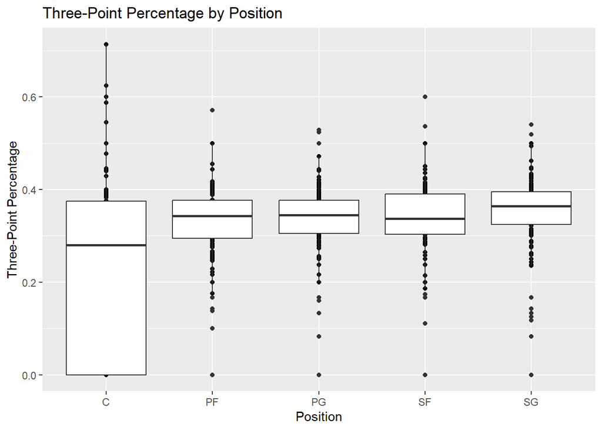

```r
three_2022_2023_NBA_Player_Stats_Regular <- data_2022_2023_NBA_Player_Stats_Regular %>% filter(`3P%` < 1.000 & `3P%` > 0.000 & `3P%` > 0.5)

center_2022_2023_NBA_Player_Stats_Regular <- data_2022_2023_NBA_Player_Stats_Regular %>% filter(`3P%` < 1.000)

ggplot(data = center_2022_2023_NBA_Player_Stats_Regular, aes(x = Pos, y = `3P%`)) +
  geom_point() +
  geom_boxplot() +
  labs(x = "Position", y = "Three-Point Percentage", title = "Three-Point Percentage by Position")
```

This graph represents the same thing as above but in more detail and better visually. This shows that everything except the center position is pretty even in 3 point percentage. It is also interesting how centers have the largest range of percentages because some don’t shoot threes at all and some specialize or “can” shoot threes.

```r
mean_pos <- aggregate(`3P%` ~ Pos, data = three_2022_2023_NBA_Player_Stats_Regular, FUN = mean, na.rm = TRUE)

print(mean_pos)
```

```
##   Pos    3P%
## 1   C 0.6144
## 2  PF 0.5710
## 3  PG 0.5265
## 4  SF 0.5685
## 5  SG 0.5295
```

This table showcases the mean three point percentage from every position. Note that I did take away the data that had 3 point percentage at a 1 and 0 so this shows the actual percentage. It is very interesting that centers are first in this category. It is probably due to the limitations that I set on this dataset.

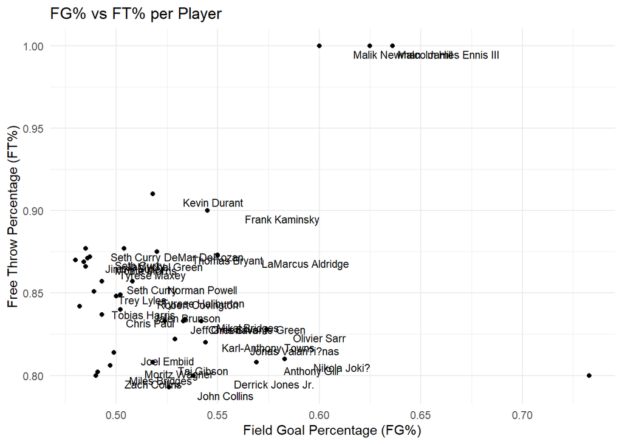

```r
high_ft_fg <- set_2021_2022_NBA_Player_Stats_Regular %>% filter(`FG%` >= 0.48 & `FT%` >= 0.79 & FTA >= 1)
two_high_ft_vs_fg <- data_2022_2023_NBA_Player_Stats_Regular %>% filter(`FG%` >= 0.5 & `FT%` >= 0.79 & FTA >= 1)

ggplot(data = high_ft_fg, aes(x = `FG%`, y = `FT%`, label = Player)) +
  geom_point() +
  geom_text(vjust = 1.5, hjust = -0.5, size = 3) +
  labs(x = "Field Goal Percentage (FG%)", y = "Free Throw Percentage (FT%)", title = "FG% vs FT% per Player") +
  theme_minimal()
```

Finally to finish off the relationship portion of this report, we will take a look at PPG vs Age in 2022-2023. This will compare NBA player’s ages to how many points per game they score.

```r
ppg_vs_age_2022_2023 <- data_2022_2023_NBA_Player_Stats_Regular %>% filter(PTS >= 20, GS > 60)
ppg_vs_age_2021_2022 <- set_2021_2022_NBA_Player_Stats_Regular %>% filter(PTS >= 20, GS > 60)

points_vs_age <- data_2022_2023_NBA_Player_Stats_Regular %>% select(PTS, Age) %>%
  mutate(PTS = case_when(PTS < 10 ~ "0 to 10  ",
                           PTS < 20 ~ "10 to 20  ",
                           PTS < 30 ~ "20 to 30  ",
                           .default = "30 and up  "))

table(points_vs_age)
```

```
##              Age
## PTS           19 20 21 22 23 24 25 26 27 28 29 30 31 32 33 34 35 36 37 38 39 42
##   0 to 10     11 24 35 39 57 43 51 27 30 18 27 20 14 14 12 14  6 11  2  0  1  1
##   10 to 20     3  4 12 13 18 16 10 17 12  8  8  9  4  8  1  7  3  1  1  0  0  0
##   20 to 30     0  2  2  3  7  2  5  7  6  4  2  4  2  2  4  3  0  0  0  1  0  0
##   30 and up    0  0  0  0  1  2  0  0  0  2  0  0  0  1  0  0  0  0  0  0  0  0
```

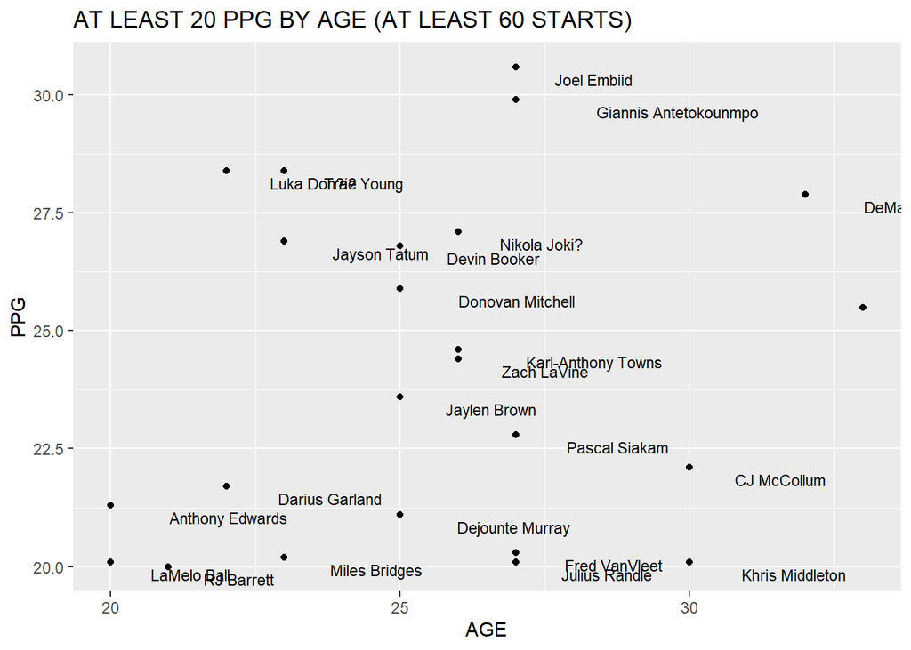

```r
ggplot(data = ppg_vs_age_2021_2022, aes(x = Age, y = PTS, label = Player)) +
  geom_point() +
  geom_text(vjust = 1.5, hjust = -0.5, size = 3) +
  labs(x = "AGE", y = "PPG", title = "AT LEAST 20 PPG BY AGE (AT LEAST 60 STARTS)")
```

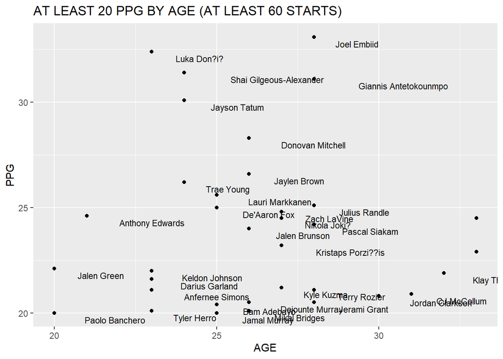

```r
ggplot(data = ppg_vs_age_2022_2023, aes(x = Age, y = PTS, label = Player)) +
  geom_point() +
  geom_text(vjust = 1.5, hjust = -0.5, size = 3) +
  labs(x = "AGE", y = "PPG", title = "AT LEAST 20 PPG BY AGE (AT LEAST 60 STARTS)")
```

These graphs show the players that started at least 60 games and averaged more than 20 points. In the 2021 season there were 24 players that met this criteria mostly being superstars but this number grew to 35 by the next season. This shows that the league is getting better with more players averaging 20 points regardless of how old they are getting.

Now we move on to predictions. To predict Points Per Game (PPG) for the 2022-2023 NBA season and beyond, I employed a linear regression model with Age, Games Started (GS), Three-Point Percentage (3P%), and Field Goal Percentage (FG%) as predictors. The initial model, lm_model, was created using these variables. To refine this model, I performed backward selection using the step function, which removes the least significant predictors until an optimal model is achieved.

```r
# Fit the linear model
lm_model <- lm(PTS ~ Age + GS + `3P%` + `FG%`, data = data_2022_2023_NBA_Player_Stats_Regular)

# Perform backward selection
backward_model <- step(lm_model, direction = "backward")
```

```
## Start:  AIC=1996.17
## PTS ~ Age + GS + `3P%` + `FG%`
##
##         Df Sum of Sq   RSS    AIC
## - Age    1      18.0 12855 1995.1
## <none>               12837 1996.2
## - `FG%`  1     117.8 12954 2000.3
## - `3P%`  1     755.1 13592 2032.7
## - GS     1   14236.2 27073 2497.1
##
## Step:  AIC=1995.11
## PTS ~ GS + `3P%` + `FG%`
##
##         Df Sum of Sq   RSS    AIC
## <none>               12855 1995.1
## - `FG%`  1     119.5 12974 1999.3
## - `3P%`  1     794.4 13649 2033.5
## - GS     1   14352.6 27207 2498.5
```

```r
summary(backward_model)
```

```
##
## Call:
## lm(formula = PTS ~ GS + `3P%` + `FG%`, data = data_2022_2023_NBA_Player_Stats_Regular)
##
## Residuals:
##      Min       1Q   Median       3Q      Max
## -15.7695  -2.4691  -0.6823   1.7261  17.4242
##
## Coefficients:
##             Estimate Std. Error t value Pr(>|t|)
## (Intercept)  1.03568    0.76691   1.350   0.1773
## GS           0.18162    0.00664  27.351  < 2e-16 ***
## `3P%`        7.76505    1.20673   6.435 2.35e-10 ***
## `FG%`        3.65445    1.46408   2.496   0.0128 *
## ---
## Signif. codes:  0 '***' 0.001 '**' 0.01 '*' 0.05 '.' 0.1 ' ' 1
##
## Residual standard error: 4.38 on 670 degrees of freedom
## Multiple R-squared:  0.5627, Adjusted R-squared:  0.5607
## F-statistic: 287.3 on 3 and 670 DF,  p-value: < 2.2e-16
```

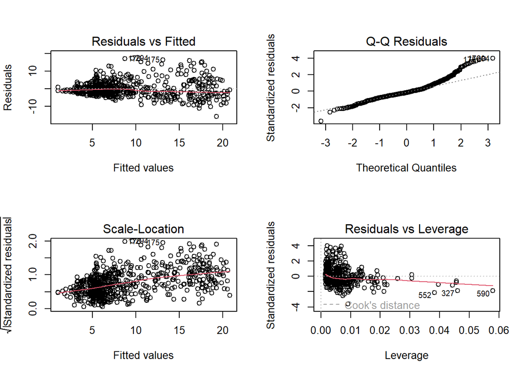

```r
par(mfrow = c(2, 2))
plot(backward_model)
```

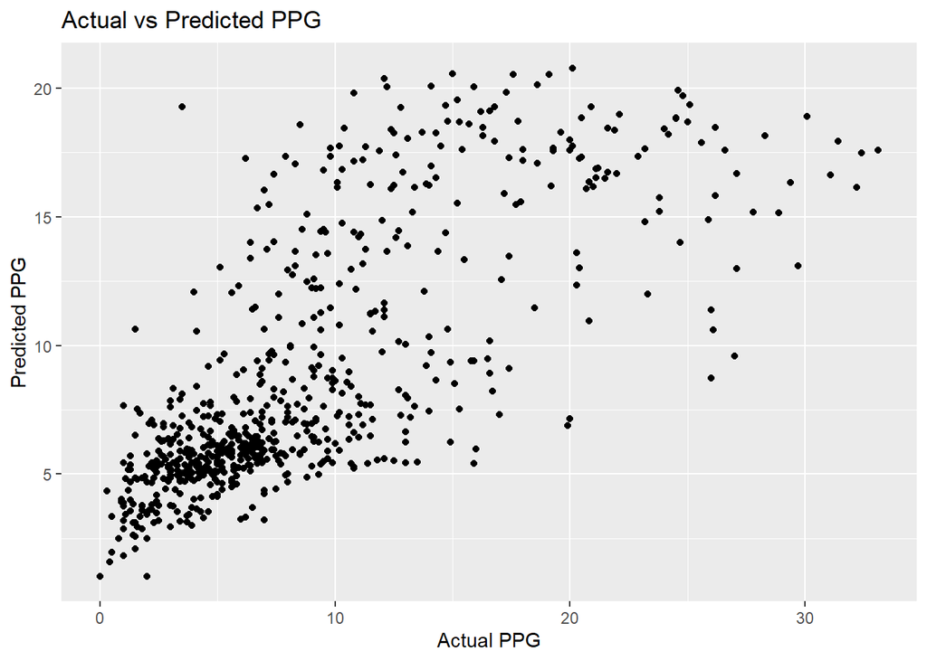

```r
predicted_ppg <- predict(backward_model, data_2022_2023_NBA_Player_Stats_Regular)
ggplot(data_2022_2023_NBA_Player_Stats_Regular, aes(x = PTS, y = predicted_ppg)) +
  geom_point() +
  labs(x = "Actual PPG", y = "Predicted PPG", title = "Actual vs Predicted PPG")
```

The coefficients table shows the estimated impact of each predictor variable on PTS. For example, each additional game started increases the PPG by approximately 0.182 points. The three-point percentage and field goal percentage also have significant positive impacts on PPG. The multiple R-squared value of 0.5627 indicates that approximately 56.27% of the variance in PPG is explained by the model. The F-statistic and p-value confirm the overall significance of the model.

For my advanced prediction model I used randomForest on a case study that focused on predicting Lebron James’s PPG based on his 2021 season.

```r
model_data <- set_2021_2022_NBA_Player_Stats_Regular %>% select(PTS, Age, GS, `3P%`, `FG%`, `FT%`, MP, `2P%`)
model_data <- model_data %>% clean_names()

# Train the Random Forest model
set.seed(123)
rf_model <- randomForest(pts ~ age + gs + x3p_percent + fg_percent + mp + x2p_percent, data = model_data, importance = TRUE)


# View the model summary and variable importance
print(rf_model)
```

```
##
## Call:
##  randomForest(formula = pts ~ age + gs + x3p_percent + fg_percent +      mp + x2p_percent, data = model_data, importance = TRUE)
##                Type of random forest: regression
##                      Number of trees: 500
## No. of variables tried at each split: 2
##
##           Mean of squared residuals: 5.176501
##                     % Var explained: 86.24
```

```r
importance(rf_model)
```

```
##               %IncMSE IncNodePurity
## age          4.848577      684.1097
## gs          22.395207     7078.7066
## x3p_percent 14.262132     2245.7966
## fg_percent  23.392815     2838.5536
## mp          67.558581    14774.6859
## x2p_percent 18.337269     1714.5724
```

```r
# Predict PPG for LeBron James
lebron_data <- set_2021_2022_NBA_Player_Stats_Regular %>% filter(Player == "LeBron James")
lebron_data <- lebron_data %>% clean_names()
lebron_predictors <- lebron_data %>% select(age, gs, x3p_percent, fg_percent, mp, x2p_percent)
lebron_predicted_ppg <- predict(rf_model, newdata = lebron_predictors)
lebron_predicted_ppg
```

```
##        1
## 26.32631
```

To demonstrate the application of this model, we predict the PPG for LeBron James using his 2021-2022 season data. LeBron’s relevant statistics such as age, games started, 3p%, fg%, minutes played, and 2p% are extracted and cleaned in the same manner as the training data. These cleaned predictor variables are then fed into the Random Forest model to generate the predicted PPG. This approach illustrates the practical use of machine learning in sports analytics, providing insights into player performance and potential future outcomes. The prediction for LeBron James offers a specific example of how the model can be used to forecast individual player performance based on their historical data. We could do this for any other player but Lebron is the most known.